# Intermediate R for social science

Fall 2018 workshop

Kumar Ramanathan

2018-12-05

# Introduction

## Outline for today

This workshop builds on Sarah Moore’s introductory R workshop from October 31, 2018.

- Last time, you learned about data types and structures, importing datasets, and basic data manipulation.
- Today, we will learn how to do some important types of tasks for social scientists, using a suite of packages called `tidyverse`.
  1. Importing, merging, and re-structuring data in the `tidyverse` way.
  2. Data transformation with `dplyr`.
  3. Data visualization with `ggplot2`.

## Our dataset(s)

We’ll use two datasets today:

- California energy data: hourly power use by generation source and imports,
- Gapminder: country-level data measured every 5 years.

# Part 1: Importing, merging, and re-structuring data in tidyverse

## Set working directory and load packages

```r
# Check working directory
getwd()
```

```
## [1] "C:/Users/kumar/OneDrive - Northwestern University - Student Advantage/Assistantships & Jobs/R training/2018 Fall Intermediate R for grad students"
```

```r
# Load tidyverse
library(tidyverse)
library(lubridate)
```

## Import your data

Do the following in your code:

- Import the `ca_generation.csv` and `ca_imports.csv` files using the `read_csv()`
- Give the data frames the same names as the data files

## Import your data

```r
# Import data using read_csv function
ca_generation <- read_csv("data/ca_generation.csv")
ca_imports <- read_csv("data/ca_imports.csv")
```

## Exploring the data (base R)

```r
str(ca_generation)
```

```
## Classes 'tbl_df', 'tbl' and 'data.frame':    168 obs. of  10 variables:
##  $ datetime   : POSIXct, format: "2018-09-03 00:00:00" "2018-09-03 01:00:00" ...
##  $ biogas     : int  239 240 237 241 240 239 238 238 239 238 ...
##  $ biomass    : int  413 413 410 410 413 419 415 413 415 414 ...
##  $ geothermal : int  974 973 973 975 975 976 975 975 970 965 ...
##  $ large_hydro: num  3282 3366 2953 2766 2716 ...
##  $ natural_gas: num  6640 5716 5208 4871 4941 ...
##  $ nuclear    : int  2244 2244 2244 2244 2244 2244 2244 2244 2244 2244 ...
##  $ small_hydro: int  297 297 297 294 295 301 379 385 405 339 ...
##  $ solar      : int  0 0 0 0 0 0 0 655 4680 8148 ...
##  $ wind       : int  2727 2528 2351 2128 1749 1326 1099 868 776 707 ...
##  - attr(*, "spec")=List of 2
##   ..$ cols   :List of 10
##   .. ..$ datetime   :List of 1
##   .. .. ..$ format: chr ""
##   .. .. ..- attr(*, "class")= chr  "collector_datetime" "collector"
##   .. ..$ biogas     : list()
##   .. .. ..- attr(*, "class")= chr  "collector_integer" "collector"
##   .. ..$ biomass    : list()
##   .. .. ..- attr(*, "class")= chr  "collector_integer" "collector"
##   .. ..$ geothermal : list()
##   .. .. ..- attr(*, "class")= chr  "collector_integer" "collector"
##   .. ..$ large_hydro: list()
##   .. .. ..- attr(*, "class")= chr  "collector_double" "collector"
##   .. ..$ natural_gas: list()
##   .. .. ..- attr(*, "class")= chr  "collector_double" "collector"
##   .. ..$ nuclear    : list()
##   .. .. ..- attr(*, "class")= chr  "collector_integer" "collector"
##   .. ..$ small_hydro: list()
##   .. .. ..- attr(*, "class")= chr  "collector_integer" "collector"
##   .. ..$ solar      : list()
##   .. .. ..- attr(*, "class")= chr  "collector_integer" "collector"
##   .. ..$ wind       : list()
##   .. .. ..- attr(*, "class")= chr  "collector_integer" "collector"
##   ..$ default: list()
##   .. ..- attr(*, "class")= chr  "collector_guess" "collector"
##   ..- attr(*, "class")= chr "col_spec"
```

## Exploring the data (dplyr)

```r
glimpse(ca_generation)
```

```
## Observations: 168
## Variables: 10
## $ datetime    <dttm> 2018-09-03 00:00:00, 2018-09-03 01:00:00, 2018-09...
## $ biogas      <int> 239, 240, 237, 241, 240, 239, 238, 238, 239, 238, ...
## $ biomass     <int> 413, 413, 410, 410, 413, 419, 415, 413, 415, 414, ...
## $ geothermal  <int> 974, 973, 973, 975, 975, 976, 975, 975, 970, 965, ...
## $ large_hydro <dbl> 3281.808, 3365.678, 2953.303, 2765.709, 2716.370, ...
## $ natural_gas <dbl> 6640.192, 5716.322, 5207.697, 4871.291, 4940.630, ...
## $ nuclear     <int> 2244, 2244, 2244, 2244, 2244, 2244, 2244, 2244, 22...
## $ small_hydro <int> 297, 297, 297, 294, 295, 301, 379, 385, 405, 339, ...
## $ solar       <int> 0, 0, 0, 0, 0, 0, 0, 655, 4680, 8148, 9409, 9969, ...
## $ wind        <int> 2727, 2528, 2351, 2128, 1749, 1326, 1099, 868, 776...
```

## Merging datasets

We have two datasets, both with observations per hour. The `generation` data tells us hourly energy use from various sources. The `imports` data tells us hourly energy use from imports. Say we want a dataset of all energy use by source during this time period. We need to *merge* the two datasets.

Since the *observations* are paired perfectly, this will be relatively easy to do. We can use the `merge()` function in base R.

## Merging datasets

Do the following in your code file:

- Open and read the help file for `merge()`
- Merge the two datasets and save the new data frame as `ca_energy`

## Merging datasets

```r
ca_energy <- merge(ca_generation, ca_imports, by="datetime")
glimpse(ca_energy)
```

```
## Observations: 168
## Variables: 11
## $ datetime    <dttm> 2018-09-03 00:00:00, 2018-09-03 01:00:00, 2018-09...
## $ biogas      <int> 239, 240, 237, 241, 240, 239, 238, 238, 239, 238, ...
## $ biomass     <int> 413, 413, 410, 410, 413, 419, 415, 413, 415, 414, ...
## $ geothermal  <int> 974, 973, 973, 975, 975, 976, 975, 975, 970, 965, ...
## $ large_hydro <dbl> 3281.808, 3365.678, 2953.303, 2765.709, 2716.370, ...
## $ natural_gas <dbl> 6640.192, 5716.322, 5207.697, 4871.291, 4940.630, ...
## $ nuclear     <int> 2244, 2244, 2244, 2244, 2244, 2244, 2244, 2244, 22...
## $ small_hydro <int> 297, 297, 297, 294, 295, 301, 379, 385, 405, 339, ...
## $ solar       <int> 0, 0, 0, 0, 0, 0, 0, 655, 4680, 8148, 9409, 9969, ...
## $ wind        <int> 2727, 2528, 2351, 2128, 1749, 1326, 1099, 868, 776...
## $ imports     <int> 7847, 7671, 7834, 7944, 7982, 8267, 8459, 8440, 62...
```

## Merging datasets

- This was a fairly simple merging exercise, since the observations are paired perfectly, and there is an “id” variable that is consistent across both datasets.
- You can specify differently named “id” variables using the `by.x =` and `by.y =` argumetns in `merge()`.
- If an id only has a row in one dataset but not another, the “new” columns for that id will be populated with missing values.
- For more complicated merging tasks, see dplyr’s suite of `join` functions (e.g. look up the help file for `left_join()`).

## Tidy data

Principles of “tidy data”:

1. Each variable must have its own column.
2. Each observation must have its own row.
3. Each value must have its own cell.

## Wide vs. long format data

Sometimes, we will want to turn our data into *long* format, where each observation-variable pair and its associated value are in separate rows. Long format data usually has three columns: an *id* column, a *variable* column, and a *value* column.

This can be useful in several contexts:

- Storing extremely large datasets with many missing values
- Doing certain data transformation tasks faster
- Manipulating the structure of the wide-format data (e.g. renaming variables based on values)
- Plotted grouped data (we will do this later today)

## Wide vs. long format data

Let’s convert the generation data into long format:

```r
ca_generation_long <- gather(ca_generation, key = "variable", value = "value", -datetime)
dim(ca_generation_long)
```

```
## [1] 1512    3
```

```r
head(ca_generation_long)
```

```
## # A tibble: 6 x 3
##   datetime            variable value
##   <dttm>              <chr>    <dbl>
## 1 2018-09-03 00:00:00 biogas     239
## 2 2018-09-03 01:00:00 biogas     240
## 3 2018-09-03 02:00:00 biogas     237
## 4 2018-09-03 03:00:00 biogas     241
## 5 2018-09-03 04:00:00 biogas     240
## 6 2018-09-03 05:00:00 biogas     239
```

## Wide vs. long format data

Do the following in your code file:

- Convert the merged energy data into long format and save it as `ca_energy_long`.
- Notice that a new object appears in your environment.
- Look at the first few rows of the new dataset using `head()`.

## Wide vs. long format data

```r
ca_energy_long <- gather(ca_energy, key = "variable", value = "value", -datetime)
head(ca_energy_long)
```

```
##              datetime variable value
## 1 2018-09-03 00:00:00   biogas   239
## 2 2018-09-03 01:00:00   biogas   240
## 3 2018-09-03 02:00:00   biogas   237
## 4 2018-09-03 03:00:00   biogas   241
## 5 2018-09-03 04:00:00   biogas   240
## 6 2018-09-03 05:00:00   biogas   239
```

# Part 2: Data transformation with dplyr

## What is dplyr?

- `dplyr` is an R package for data manipulation developed by R Studio
- Principles: consistent syntax, meaningful naming conventions, fewer arguments/more functions - It contains *verbs* that help you transform data in straightforward ways
- https://dplyr.tidyverse.org/

## dplyr verbs

The core functions in `dplyr`, which are all “verbs” that perform common actions, are:

- `select`: select or exclude certain variables
- `filter`: subset observations based on conditions
- `arrange`: order rows based on conditions
- `mutate`: add new variables
- `summarize`: reduce multiple observations to a single value (e.g., find the mean of all data, or within groups)

## select()

The `select()` function allows you to select specific columns from a data frame. Note that in all dplyr functions, the data frame is the first argument.

```r
temp <- select(ca_energy, datetime, biomass, biogas)
glimpse(temp)
```

```
## Observations: 168
## Variables: 3
## $ datetime <dttm> 2018-09-03 00:00:00, 2018-09-03 01:00:00, 2018-09-03...
## $ biomass  <int> 413, 413, 410, 410, 413, 419, 415, 413, 415, 414, 412...
## $ biogas   <int> 239, 240, 237, 241, 240, 239, 238, 238, 239, 238, 239...
```

## Exercise 1: select()

Do the following in your code file:

- Create a data frame called `temp` containing the variables `datetime`, `small_hydro`, `large_hydro`.
- Check your results by using the `names()` or `glimpse()` functions.
- Create a data frame called `temp2` from `ca_energy` with all variables *except* `nuclear`. To do this, you can use a `-` operator before the variable you want to exclude, instead of naming all the ones you want to include.

## Exercise 1: select()

```r
temp <- select(ca_energy, datetime, small_hydro, large_hydro)
names(temp)
```

```
## [1] "datetime"    "small_hydro" "large_hydro"
```

```r
temp2 <- select(ca_energy, -nuclear)
names(temp2)
```

```
##  [1] "datetime"    "biogas"      "biomass"     "geothermal"  "large_hydro"
##  [6] "natural_gas" "small_hydro" "solar"       "wind"        "imports"
```

## select() helper functions

You can use helper functions to select variables: `contains()`, `starts_with()`, `ends_with()`, and `matches()`. For example:

```r
select(ca_energy, datetime, contains("hydro"))
```

```
##                datetime large_hydro small_hydro
## 1   2018-09-03 00:00:00    3281.808         297
## 2   2018-09-03 01:00:00    3365.678         297
## 3   2018-09-03 02:00:00    2953.303         297
## 4   2018-09-03 03:00:00    2765.709         294
## 5   2018-09-03 04:00:00    2716.370         295
## 6   2018-09-03 05:00:00    2830.184         301
## 7   2018-09-03 06:00:00    3303.840         379
## 8   2018-09-03 07:00:00    3317.822         385
## 9   2018-09-03 08:00:00    2719.037         405
## 10  2018-09-03 09:00:00    1957.958         339
## 11  2018-09-03 10:00:00    1768.795         262
## 12  2018-09-03 11:00:00    2378.944         260
## 13  2018-09-03 12:00:00    2276.814         260
## 14  2018-09-03 13:00:00    2926.387         301
```

[output cut: 154 more lines]

## filter()

The `filter()` function lets you subset observations in a data frame using defined conditions. For example:

```r
filter(ca_energy, solar > 10000, wind > 1000)
```

```
##              datetime biogas biomass geothermal large_hydro natural_gas
## 1 2018-09-09 14:00:00    234     399        899    3243.954    7110.046
##   nuclear small_hydro solar wind imports
## 1    2244         273 10085 1410    5127
```

## Exercise 2: filter()

Do the following in your code file:

- Calculate the number of rows where wind is higher than 500.
- Calculate the number of rows where there is more energy generated by wind power than solar power.

## Exercise 2: filter()

```r
nrow(filter(ca_energy, wind > 500))
```

```
## [1] 158
```

```r
nrow(filter(ca_energy, wind > solar))
```

```
## [1] 90
```

## Pipes: dplyr’s magic ingredient

```r
temp <- ca_energy %>% filter(large_hydro > imports) %>% select(datetime, imports)
temp
```

```
##              datetime imports
## 1 2018-09-04 16:00:00    5796
## 2 2018-09-05 14:00:00    4061
## 3 2018-09-05 15:00:00    4570
## 4 2018-09-05 16:00:00    5131
## 5 2018-09-06 15:00:00    4509
## 6 2018-09-06 16:00:00    5343
```

## Exercise 3: Pipes

Do the following in your code file:

- Identify the rows where both imports and large hydro are above 7500, and print out the datetime and values for solar, wind, and nuclear for these rows.

## Exercise 3: Pipes

```r
ca_energy %>%
    filter(imports > 7500, large_hydro > 7500) %>%
    select(datetime, solar, wind, nuclear)
```

```
##              datetime solar wind nuclear
## 1 2018-09-06 19:00:00   220 1792    2244
## 2 2018-09-06 20:00:00    21 2279    2244
## 3 2018-09-07 19:00:00   217 2399    2244
```

## mutate()

```r
ca_energy <- ca_energy %>% mutate(log_imports = log(imports))
names(ca_energy)
```

```
##  [1] "datetime"    "biogas"      "biomass"     "geothermal"  "large_hydro"
##  [6] "natural_gas" "nuclear"     "small_hydro" "solar"       "wind"
## [11] "imports"     "log_imports"
```

## Exercise 4: mutate()

Do the following in your own code file:

- Create a new variable called `all_hydro` by summing `small_hydro` and `large_hydro`.
- Make sure to save the results of your mutated data frame to `ca_energy`.
- Calculate the mean of `all_hydro`.

## Exercise 4: mutate()

```r
ca_energy <- ca_energy %>%
    mutate(all_hydro = small_hydro + large_hydro)

mean(ca_energy$all_hydro)
```

```
## [1] 4557.714
```

## group_by() and summarize()

Two very poweful verbs in dplyr are `group_by()` and `summarize()`. Used in two steps, you can group a data frame by a certain varaible, and calculate summary statistics within each group.

This is a situation in which using long format data is helpful. Recall the structure of the long format data:

```r
ca_energy_long[c(1,100,500,1000),]
```

```
##                 datetime   variable value
## 1    2018-09-03 00:00:00     biogas   239
## 100  2018-09-07 03:00:00     biogas   238
## 500  2018-09-09 19:00:00 geothermal   938
## 1000 2018-09-09 15:00:00    nuclear  2244
```

## group_by() and summarize()

```r
ca_energy_long %>%
    group_by(variable) %>%
    summarize(average = mean(value))
```

```
## # A tibble: 10 x 2
##    variable    average
##    <chr>         <dbl>
##  1 biogas         234.
##  2 biomass        385.
##  3 geothermal     950.
##  4 imports       6962.
##  5 large_hydro   4213.
##  6 natural_gas   8057.
##  7 nuclear       2244
##  8 small_hydro    345
##  9 solar         3818.
## 10 wind          1709.
```

## group_by() and summarize()

Pipes are very powerful. You can create long format data and pipe it directly into the dplyr verbs.

```r
ca_energy %>%
    gather(key="variable", value="value", -datetime) %>%
    group_by(variable) %>%
    summarize(average = mean(value))
```

```
## # A tibble: 11 x 2
##    variable    average
##    <chr>         <dbl>
##  1 all_hydro     4558.
##  2 biogas         234.
##  3 biomass        385.
##  4 geothermal     950.
##  5 imports       6962.
##  6 large_hydro   4213.
##  7 natural_gas   8057.
##  8 nuclear       2244
##  9 small_hydro    345
## 10 solar         3818.
## 11 wind          1709.
```

## Exercise 5: group_by() and summarize()

Let’s put together a few things you’ve learned, and calculate the total energy used per day. For that, we need to do the following:

- Start with the long format data.
- Earlier we installed a package called `lubridate`, which contains a function called `as_date()`, which can turn date-time values into date values. Use this function within `mutate()` to create a new variable called `date`.
- Use `group_by()` and `summarize()` to calculate the *total* energy used across all sources per day.

## Exercise 5: group_by() and summarize()

```r
ca_energy_long %>%
    mutate(date = as_date(datetime)) %>%
    group_by(date) %>%
    summarize(total = sum(value))
```

```
## # A tibble: 7 x 2
##   date         total
##   <date>       <dbl>
## 1 2018-09-03 644186
## 2 2018-09-04 705620.
## 3 2018-09-05 706916.
## 4 2018-09-06 704064.
## 5 2018-09-07 725994.
## 6 2018-09-08 703440.
## 7 2018-09-09 667599.
```

# Part 3: Data visualization with ggplot2

## What is ggplot?

Part of the `tidyverse`, `ggplot2` is an R package that implements the “grammar of graphics” in R.

In ggplot, graphics are built by supplying *data* and *mapping* of data values to aesthetics, and then adding *layers* that build geometric objects, scales, labels, and more.

What are the advantages of ggplot?

- Highly customizable and extensible.
- Designed to work with `dplyr` and other `tidyverse` packages.
- In use for over 10 years, meaning that help is widely available.
- Wide variety of avilable [extensions](http://www.ggplot2-exts.org/gallery/)

## Useful resources

- The [ggplot cheatsheet](https://github.com/rstudio/cheatsheets/blob/master/data-visualization-2.1.pdf)
- The [ggplot reference guide](https://ggplot2.tidyverse.org/reference/index.html)
- The [Data Visualization chapter](http://r4ds.had.co.nz/data-visualisation.html) in the “R for Data Science” book
- And, of course, the help files that come with the package itself.

## Components of a basic plot

- **data**: a data frame, provided to the `ggplot()` function
- **geometric objects**: the objects/shapes that you want to plot, indicated through one of the many available `geom` functions, such as `geom_point()` or `geom_hist()`
- **aesthetic mapping**: the mapping from the data to the geometric objects, provided in an `aes()` function nested within the chosen `geom` function
- connected with the `+` operator

```r
ggplot(data = <DATA FRAME>) +
  <GEOM_FUNCTION>(mapping = aes(<VARIABLES>))
```

## Example with a new dataset

Let’s bring in a new dataset called `gapminder`. Run this code in your code file.

```r
gapminder <- read_csv("data/gapminder.csv")
glimpse(gapminder)
```

```
## Observations: 1,704
## Variables: 6
## $ country   <chr> "Afghanistan", "Afghanistan", "Afghanistan", "Afghan...
## $ year      <int> 1952, 1957, 1962, 1967, 1972, 1977, 1982, 1987, 1992...
## $ pop       <dbl> 8425333, 9240934, 10267083, 11537966, 13079460, 1488...
## $ continent <chr> "Asia", "Asia", "Asia", "Asia", "Asia", "Asia", "Asi...
## $ lifeExp   <dbl> 28.801, 30.332, 31.997, 34.020, 36.088, 38.438, 39.8...
## $ gdpPercap <dbl> 779.4453, 820.8530, 853.1007, 836.1971, 739.9811, 78...
```

## Example with a new dataset

Now, make a subset of the data with only rows from the year 2007. Save the new data frame as `gapminder07`.

## Example with a new dataset

Now, make a subset of the data with only rows from the year 2007. Save the new data frame as `gapminder07`.

```r
gapminder07 <- gapminder %>% filter(year==2007)
```

## Example: GDP over life expectancy in 2007

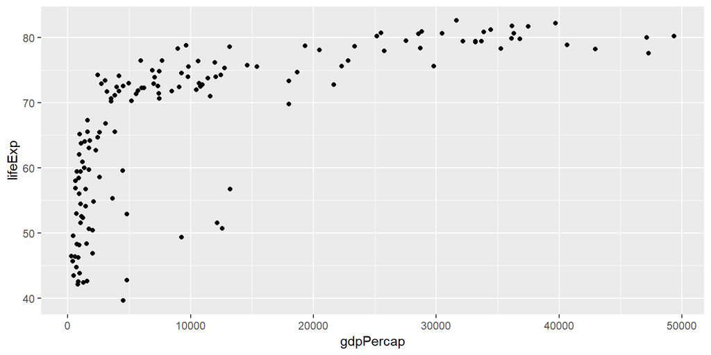

```r
ggplot(data = gapminder07) +
  geom_point(mapping = aes(x = gdpPercap, y = lifeExp))
```

## Example: GDP over life expectancy in 2007

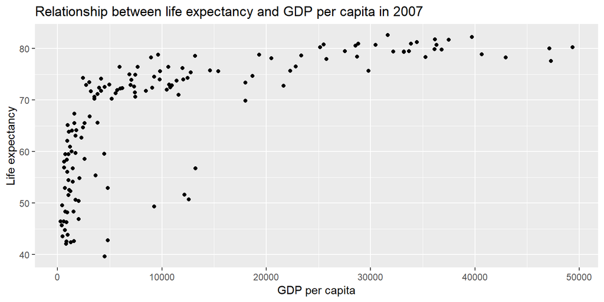

```r
ggplot(gapminder07) +
  geom_point(aes(x = gdpPercap, y = lifeExp)) +
  labs(title = "Relationship between life expectancy and GDP per capita in 2007",
       x = "GDP per capita", y = "Life expectancy")
```